# Lecture 9 - Two-way ANOVA

Author: Matthew J. Cossley

Last update: 17 May, 2022

## Two-way ANOVA

Consider an experiment in which one of two different **treatments** are administered at one of two different **doses**. A two-way ANOVA attempts to answer the following three questions:

1. Do different treatments lead to different outcomes?
2. Do different doses lead to different outcomes?
3. Does treatment and dose interact?

## Two-way ANOVA Intuition

The logic of a two-way ANOVA is essentially the same as for a one-way ANOVA. That is, if between-group variation is significantly larger than within-group variation, then we have evidence that different groups have different means. However, with a two-way ANOVA, between-group and withing-group aren’t quite as easily defined, because there are many groups for observations to fall between or within. The basic approach to dealing with this is to see that a two-way ANOVA is actually testing three null hypotheses simultaneously (i.e., the three statements above).

## Visualising the three null hypotheses

Consider the simple example of two treatments $A$ and $B$, both with two treatment doses.

### Example 1 - No main effects and no interaction

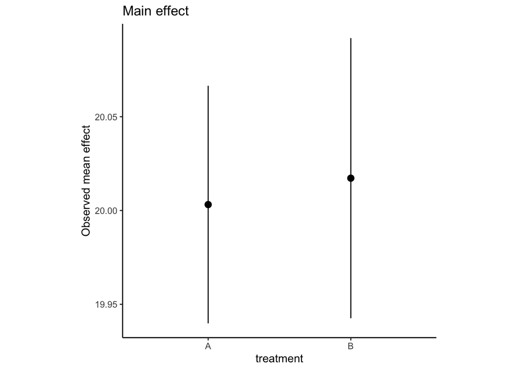

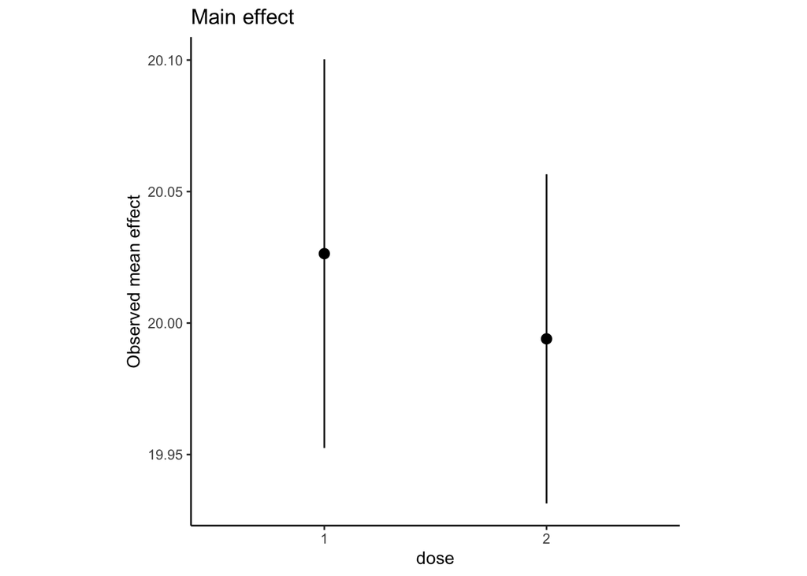

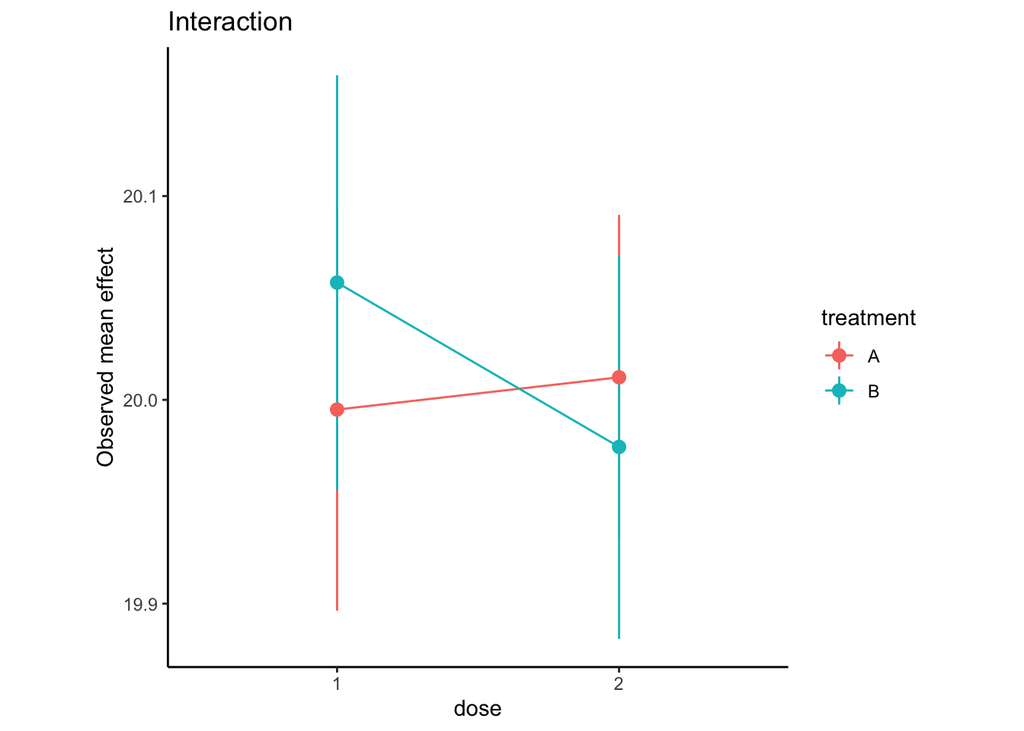

### Example 2 - No main effects but with an interaction

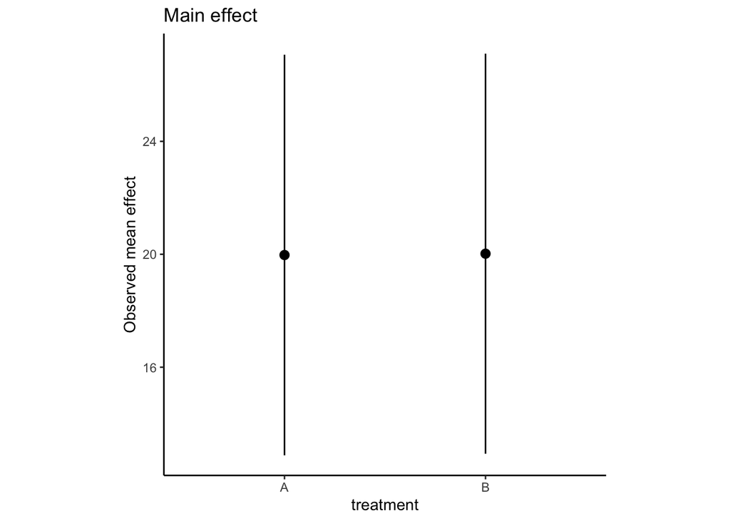

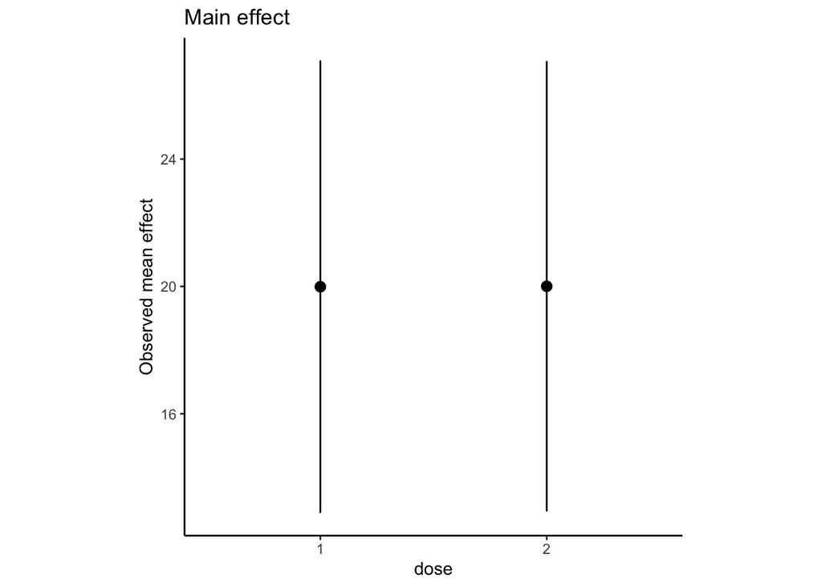

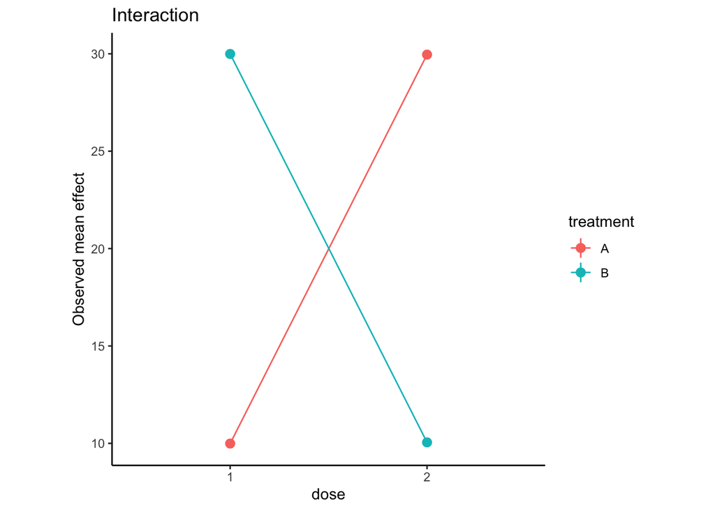

### Example 3 - Two main effects but no interaction

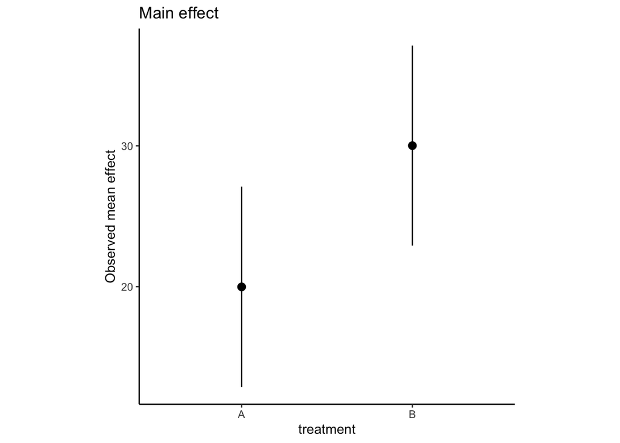

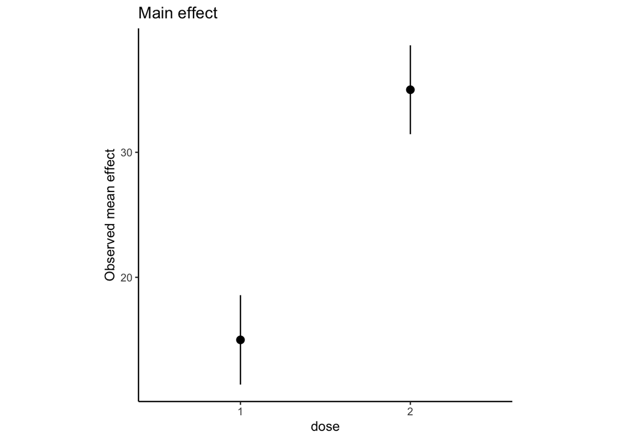

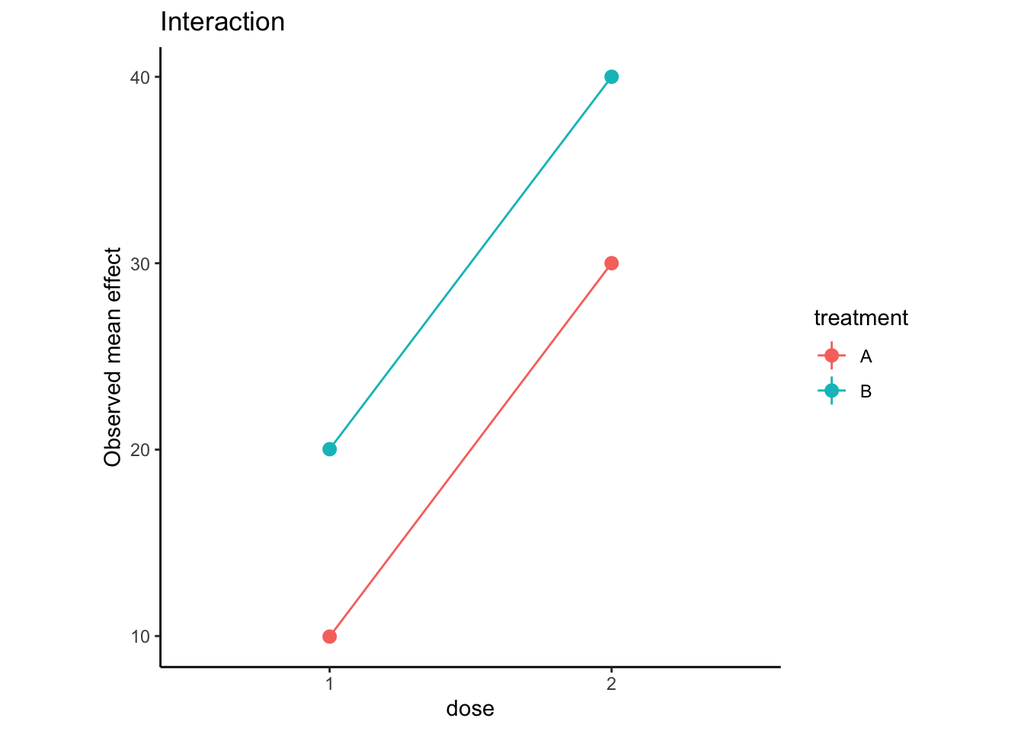

### Example 4 - Two main effects and an interaction

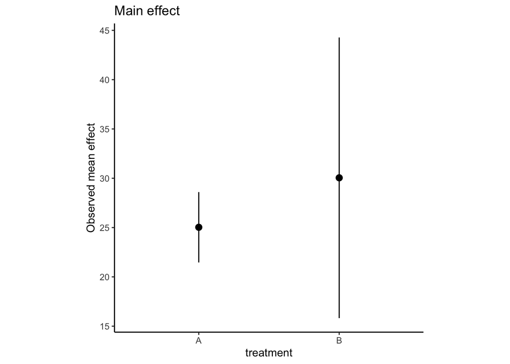

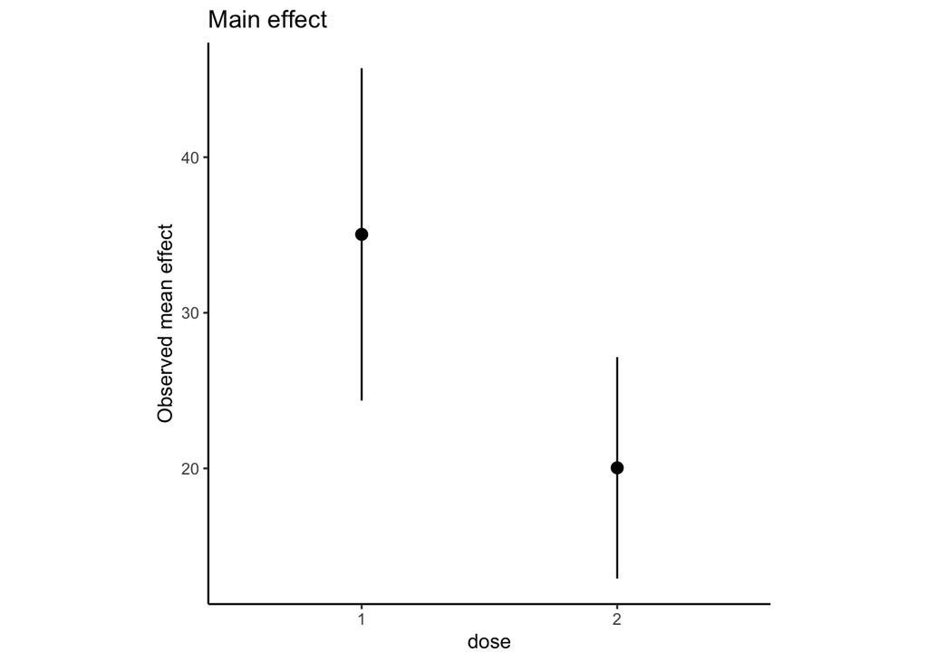

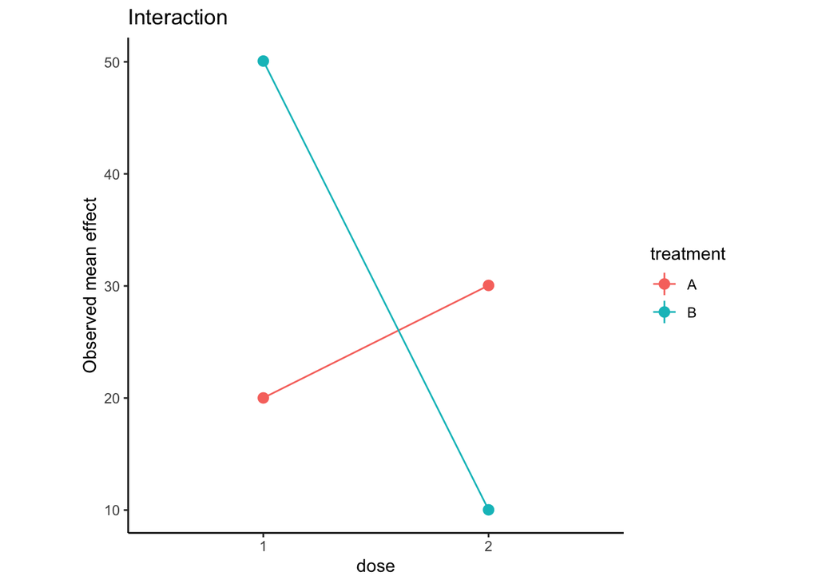

## Two-way ANOVA more formally

To talk about a two-way ANOVA clearly, it is helpful to introduce the following new nomenclature:

- Let $y_{ijk}$ be the $k^{th}$ observation obtained for treatment $i$ and dose $j$. In this example, $i \in \{A, B\}$, $j \in \{1, 2\}$, and $k \in \{1,2,...,n_{i,j}\}$, where $n_{i,j}$ is the number of observations in the corresponding condition.
- Let $\bar{y}_{ij \bullet}$ indicate the mean effect observed for treatment $i$ and dose $j$.
- Let $\bar{y}_{\bullet j \bullet}$ indicate the mean effect observed for dose $j$, averaged over all possible treatments.
- Let $\bar{y}_{i \bullet \bullet}$ indicate the mean effect observed for treatment $i$, averaged over all possible doses.
- Let $\bar{y}_{\bullet \bullet \bullet}$ indicate the mean averaged over all possible treatments and doses.

For this simple case in which we have only two treatments $A$ and $B$, only two doses, and we have exactly $n$ observations for each treatment at each dose, our data looks as follows:

|  | Treatment A | Treatment B |  |
| --- | --- | --- | --- |
| Dose 1 | $\bar{y}_{11\bullet} = \frac{y_{111}+y_{112}+\ldots+y_{11n}}{n}$ | $\bar{y}_{21\bullet} = \frac{y_{121}+y_{122}+\ldots+y_{12n}}{n}$ | $\bar{y}_{\bullet 1 \bullet}$ |
| Dose 2 | $\bar{y}_{12\bullet} = \frac{y_{211}+y_{212}+\ldots+y_{11n}}{n}$ | $\bar{y}_{22\bullet} = \frac{y_{221}+y_{222}+\ldots+y_{22n}}{n}$ | $\bar{y}_{\bullet 2 \bullet}$ |
|  | $\bar{y}_{1 \bullet \bullet}$ | $\bar{y}_{2 \bullet \bullet}$ | $\bar{y}_{\bullet \bullet \bullet}$ |

Please note that this is called a **[full factorial experiment](https://en.wikipedia.org/wiki/Factorial_experiment)**.

With this convention, we can write the H’s as follows:

$\begin{align} & H_{0_1}: \mu_{Treatment_A} = \mu_{Treatment_B} \\ & H_{0_2}: \mu_{Dose_1} = \mu_{Dose_2} \\ & H_{0_3}: \mu_{Treatment_i | Dose_j} = \mu_{Treatment_i | Dose_j} \\\\ & H_1: \lnot H_0 \\ \end{align}$

### Using variance to test the null hypotheses

- $SS_{total}$ is the total variability between all observations.
- $SS_{treatment}$ is the variability between different treatments.
- $SS_{dose}$ is the variability between different doses.
- $SS_{treatment \times dose}$ is the variability between different treatments at different dose levels.
- $SS_{error}$ is the variability not accounted for by $SS_{treatment}$, $SS_{dose}$, and $SS_{treatment \times dose}$

### Variability terms akin to *between-factor* variability

- $n_{treatment} =$ number of unique treatment levels.
- $n_{dose} =$ number of unique dose levels.
- $n_{total} =$ number of observations at level of dose and treatment, which in the following we assume is the same for all combinations of treatment and dose (i.e., we assume a **balanced design**).

$$\begin{align}
SS_{treatment} &= n_{dose} n_{total} \sum_i^{ n_{treatment} }
(\bar{y}_{i \bullet \bullet} -
\bar{y}_{\bullet \bullet \bullet})^2 \\
SS_{dose} &= n_{treatment} n_{total} \sum_j^{ n_{dose} } (\bar{y}_{\bullet j \bullet} -
\bar{y}_{\bullet \bullet \bullet})^2 \\
SS_{treatment \times dose} &= n_{total} \sum_i^{ n_{treatment} } \sum_j^{ n_{dose} }
\left(
\bar{y}_{i j \bullet} -
(\bar{y}_{i \bullet \bullet} +
\bar{y}_{\bullet j \bullet} -
\bar{y}_{\bullet \bullet \bullet} )
\right)^2 \\
\end{align}$$

### Variability terms akin to *within-factor* variability

$$\begin{align}
SS_{error} &= \sum_i^{ n_{treatment} } \sum_j^{ n_{dose} } \sum_k^{ n_{total} }
\left(
\bar{y}_{i j k} -
\bar{y}_{i j \bullet}
\right)^2 \\
\end{align}$$

### Total variability

$$\begin{align}
SS_{Total} &= \sum_i^{ n_{treatment} } \sum_j^{ n_{dose} } \sum_k^{ n_{total} }
\left(
\bar{y}_{i j k} -
\bar{y}_{\bullet \bullet \bullet}
\right)^2 \\
\end{align}$$

- Note that you can think of the $n_{treatment}$, $n_{dose}$, and $n_{total}$ multipliers above serve to cast each $SS$ term into the same units so that they can be meaningfully compared. You can also think of them as ensuring that $SS_{total}$ is the sum of all the other sources of variability.

$$SS_{total} = SS_{treatment} + SS_{dose} + SS_{treatment \times dose} + SS_{error}$$

### Degrees of freedom and building F-ratios

| Effect | $df$ | $SS$ | $MS$ | $F$ |
| --- | --- | --- | --- | --- |
| $Treatment$ | $n_{treatment} - 1$ | see above | $\frac{SS_{treatment}}{df_{treatment}}$ | $\frac{MS_{treatment}}{MS_{error}}$ |
| $Dose$ | $n_{dose} - 1$ | see above | $\frac{SS_{dose}}{df_{dose}}$ | $\frac{MS_{dose}}{MS_{error}}$ |
| $Treatment \times Dose$ | $(n_{treatment} - 1)(n_{dose} - 1)$ | see above | $\frac{SS_{treatment \times dose}}{df_{treatment \times dose}}$ | $\frac{MS_{treatment \times dose}}{MS_{error}}$ |
| $Error$ | $N - n_{treatment}n_{dose}$ | see above | $\frac{SS_{error}}{df_{error}}$ |  |

- From here, we compute p-values from the observed $F$ scores in the table above, and we are off to the hypothesis testing races.

### More general experiment and data structure

More generally, two-way ANOVA deals with any two factors of an experiment that contain an arbitrary number of levels. Consider a full factorial experiment with two factors: Factor 1 containing $n_1$ levels and Factor 2 containing $n_2$ levels.

|  | Factor 2 level 1 | Factor 2 level 2 | $\ldots$ | Factor 2 level $n_1$ |  |
| --- | --- | --- | --- | --- | --- |
| Factor 1 level 1 | $\bar{y}_{11\bullet}$ | $\bar{y}_{12\bullet}$ | $\ldots$ | $\bar{y}_{1 n_2 \bullet}$ | $\bar{y}_{1 \bullet \bullet}$ |
| Factor 1 level 2 | $\bar{y}_{21\bullet}$ | $\bar{y}_{22\bullet}$ | $\ldots$ | $\bar{y}_{2 n_2 \bullet}$ | $\bar{y}_{2 \bullet \bullet}$ |
| $\vdots$ | $\vdots$ | $\vdots$ | $\vdots$ | $\vdots$ | $\vdots$ |
| Factor 1 level $n_1$ | $\bar{y}_{n_1 1 \bullet}$ | $\bar{y}_{n_1 2 \bullet}$ | $\ldots$ | $\bar{y}_{n_1 n_2 \bullet}$ | $\bar{y}_{n_1 \bullet \bullet}$ |
|  | $\bar{y}_{\bullet 1 \bullet}$ | $\bar{y}_{\bullet 2 \bullet}$ | $\ldots$ | $\bar{y}_{\bullet n_2 \bullet}$ | $\bar{y}_{\bullet \bullet \bullet}$ |

- This more general situation doesn’t change our method at all.
- We still proceed by generating the ANOVA table:

| Effect | $df$ | $SS$ | $MS$ | $F$ |
| --- | --- | --- | --- | --- |
| $Factor 1$ | $n_{Factor 1} - 1$ | see above | $\frac{SS_{Factor 1}}{df_{Factor 1}}$ | $\frac{MS_{Factor 1}}{MS_{error}}$ |
| $Factor 2$ | $n_{Factor 2} - 1$ | see above | $\frac{SS_{Factor 2}}{df_{Factor 2}}$ | $\frac{MS_{Factor 2}}{MS_{error}}$ |
| $Factor 1 \times Factor 2$ | $(n_{Factor 1}-1) (n_{Factor 2}-1)$ | see above | $\frac{SS_{Factor 1 \times Factor 2}}{df_{Factor 1 \times Factor 2}}$ | $\frac{MS_{Factor 1 \times Factor 2}}{MS_{error}}$ |
| $Error$ | $N - n_{Factor 1}n_{Factor 2}$ | see above | $\frac{SS_{error}}{df_{error}}$ |  |

## Two-way ANOVA in R

Consider the following data:

```
##             y treatment dose
##  1: 16.314771         A    1
##  2:  8.368833         A    1
##  3: 16.648996         A    1
##  4: 16.362147         A    1
##  5: 32.073207         A    2
##  6: 22.300250         A    2
##  7: 25.357165         A    2
##  8: 28.526398         A    2
##  9: 19.971164         B    1
## 10: 32.023267         B    1
## 11: 23.817967         B    1
## 12: 16.004954         B    1
## 13: 34.261715         B    2
## 14: 38.552692         B    2
## 15: 38.503924         B    2
## 16: 37.942446         B    2
```

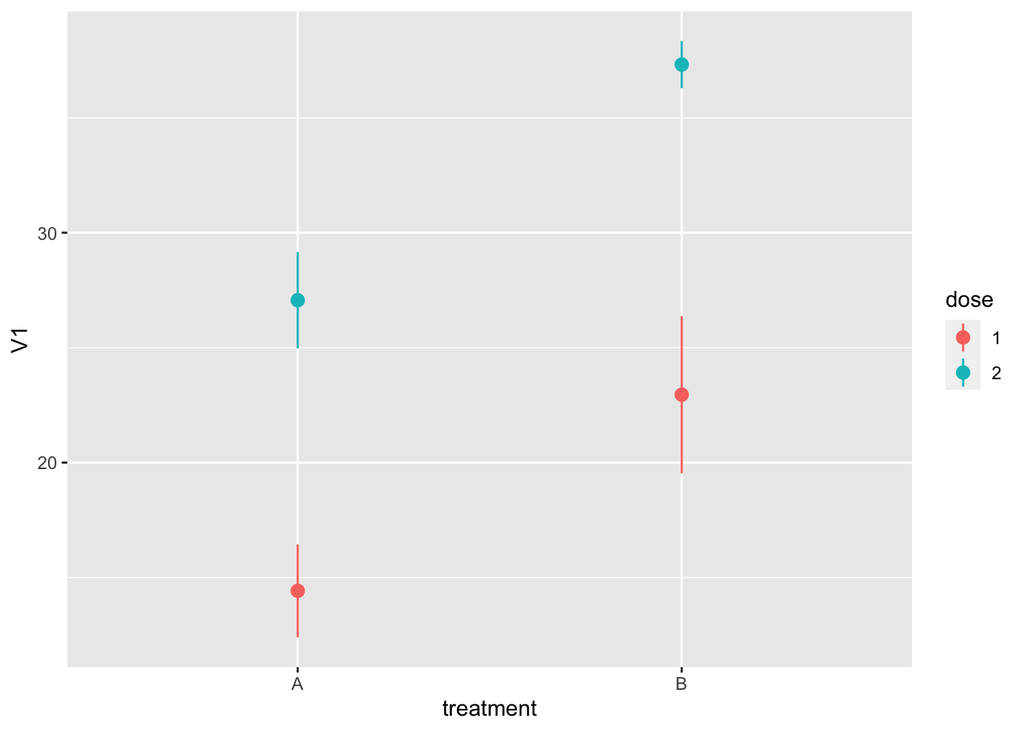

```r
y <- c(16.314771, 8.368833, 16.648996, 16.362147,
       32.073207, 22.300250, 25.357165, 28.526398,
       19.971164, 32.023267, 23.817967, 16.004954,
       34.261715, 38.552692, 38.503924, 37.942446)

treatment <- c( "A", "A", "A", "A", "A", "A", "A", "A",
                "B", "B",  "B", "B", "B", "B", "B", "B")

dose <- c( 1, 1, 1, 1, 2, 2, 2, 2, 1, 1, 1, 1, 2, 2, 2, 2)

d <- data.table(y=y,
                treatment=as.factor(treatment),
                dose=as.factor(dose))

# generate intuition about results before doing the analysis
# (looks like two main effects but no interaction)
dd <- d[, .(mean(y), sd(y)/sqrt(.N)), .(treatment, dose)]
ggplot(dd, aes(treatment, V1, colour=dose)) +
  geom_pointrange(aes(ymin=V1-V2, ymax=V1+V2))
```

```r
## define number of levels in each factor
n_treatment <- d[, length(unique(treatment))] # number of treatment levels
n_dose <- d[, length(unique(dose))] # number of dose levels
n <- d[, .N, .(treatment, dose)][, unique(N)] # number of observations at each level

## define Df terms
df_treatment <- n_treatment - 1
df_dose <- n_dose - 1
df_interaction <- df_treatment * df_dose
df_error <- d[, .N] - n_treatment*n_dose

## Define SS terms
ss_treatment <- 0
for(i in d[, unique(treatment)]) {
  ss_treatment <- ss_treatment + (d[treatment==i, mean(y)] - d[, mean(y)])^2
}
ss_treatment <- n_dose * n * ss_treatment

ss_dose <- 0
for(i in d[, unique(dose)]) {
  ss_dose <- ss_dose + (d[dose==i, mean(y)] - d[, mean(y)])^2
}
ss_dose <- n_treatment * n * ss_dose

ss_interaction <- 0
for(i in d[, unique(treatment)]) {
  for(j in d[, unique(dose)]) {
    ss_interaction <- ss_interaction +
      (d[treatment==i & dose==j, mean(y)] -
       (d[treatment==i, mean(y)] + d[dose==j, mean(y)] - d[, mean(y)]))^2
  }
}
ss_interaction <- n * ss_interaction

ss_error <- 0
for(i in d[, unique(treatment)]) {
  for(j in d[, unique(dose)]) {
    for(k in 1:n) {
      ss_error <- ss_error + (d[treatment==i & dose==j][k, y] -
                              d[treatment==i & dose==j, mean(y)])^2
    }
  }
}
ss_error <- ss_error

## Define MS terms
ms_treatment <- ss_treatment / df_treatment
ms_dose <- ss_dose / df_dose
ms_interaction <- ss_interaction / df_interaction
ms_error <- ss_error / df_error

## Define F terms
f_treatment <- ms_treatment / ms_error
f_dose <- ms_dose / ms_error
f_interaction <- ms_interaction / ms_error

## Define Pr(>F)
p_treatment <- pf(f_treatment, df_treatment, df_error, lower.tail=F)
p_dose <- pf(f_dose, df_dose, df_error, lower.tail=F)
p_interaction <- pf(f_interaction, df_interaction, df_error, lower.tail=F)

## NOTE: Lots of things to print out here, so I'll leave
## this to a live demo and your own personal tinkering
## around to see the actual values and confirm that they
## match the anova() method below.

## Verify results
fm <- lm(y ~ treatment*dose, data=d)
anova(fm)
```

```
## Analysis of Variance Table
##
## Response: y
##                Df Sum Sq Mean Sq F value    Pr(>F)
## treatment       1 352.75  352.75 16.6240  0.001534 **
## dose            1 729.08  729.08 34.3593 7.697e-05 ***
## treatment:dose  1   2.96    2.96  0.1395  0.715325
## Residuals      12 254.63   21.22
## ---
## Signif. codes:  0 '***' 0.001 '**' 0.01 '*' 0.05 '.' 0.1 ' ' 1
```

```r
# Using ezANOVA
d[, subject := 1:.N]
ezANOVA(data=d,
        dv=y,
        wid=subject,
        between=.(treatment, dose),
        type=3)
```

```
## Coefficient covariances computed by hccm()
```

```
## $ANOVA
##           Effect DFn DFd          F           p p<.05        ges
## 2      treatment   1  12 16.6239881 1.53355e-03     * 0.58077121
## 3           dose   1  12 34.3592629 7.69696e-05     * 0.74115205
## 4 treatment:dose   1  12  0.1394674 7.15325e-01       0.01148876
##
## $`Levene's Test for Homogeneity of Variance`
##   DFn DFd      SSn     SSd        F         p p<.05
## 1   3  12 31.57735 113.392 1.113918 0.3818176
```

## Two-way ANOVA in R using real data

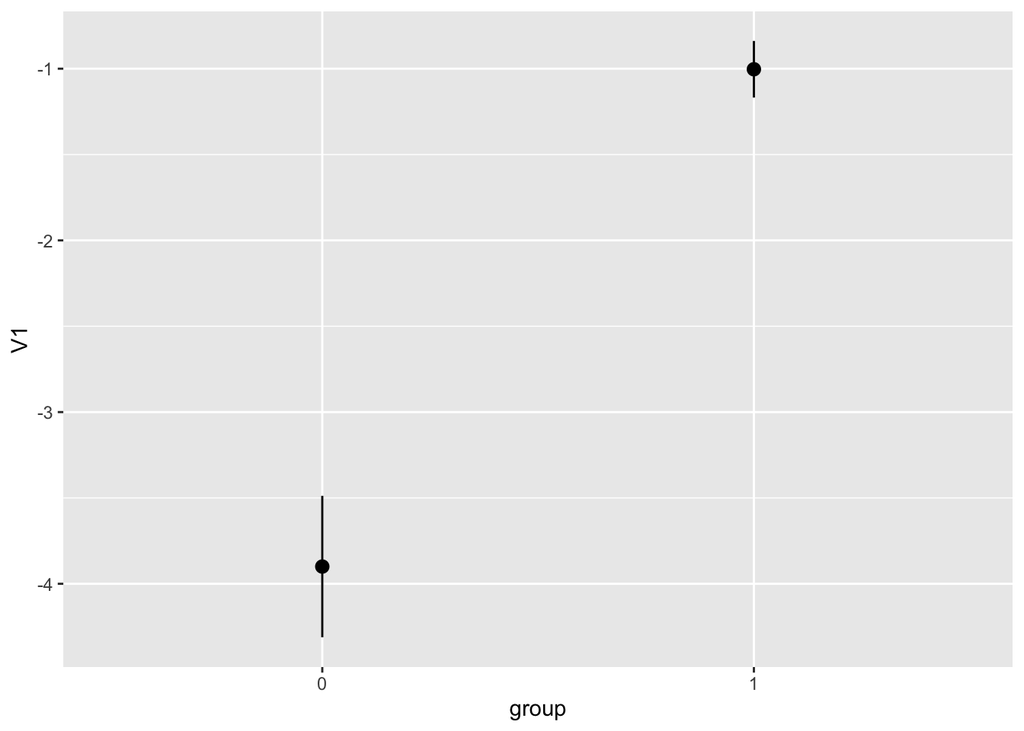

```r
d <- fread('https://crossley.github.io/cogs2020/data/mis/mis_data.csv')

d <- d[phase=='Base', .(subject, group, target, error)]
d[, group := factor(group)]
d[, target := factor(target)]

## First, get one observation per subject per group per target
dd <- d[, mean(error), .(subject, group, target)]

## Do different groups have different mean errors?
## Do different targets have different mean errors?
## Does target and group interact?

## begin by making diagnostic plots
ddd <- dd[, .(mean(V1), sd(V1)/sqrt(length(unique(target)))), .(group)]
ggplot(ddd, aes(group, V1)) +
  geom_pointrange(aes(ymin=V1-V2, ymax=V1+V2))
```

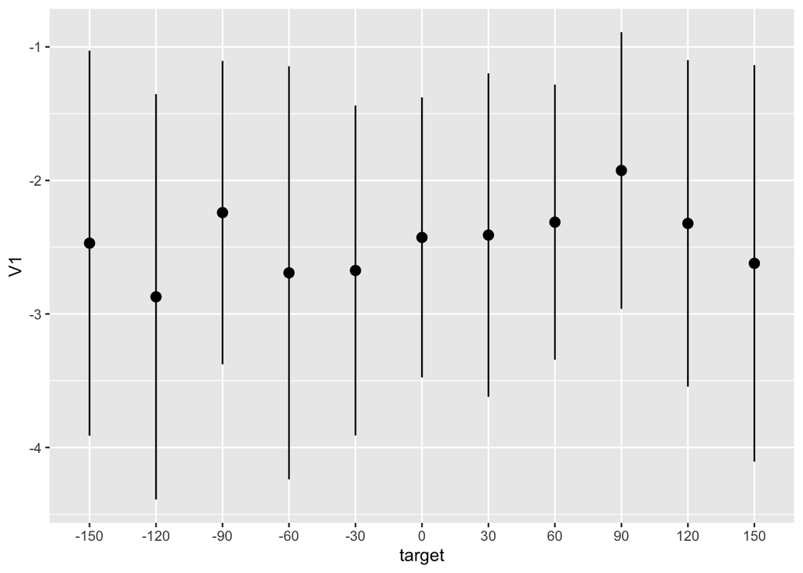

```r
ddd <- dd[, .(mean(V1), sd(V1)/sqrt(length(unique(group)))), .(target)]
ggplot(ddd, aes(target, V1)) +
  geom_pointrange(aes(ymin=V1-V2, ymax=V1+V2))
```

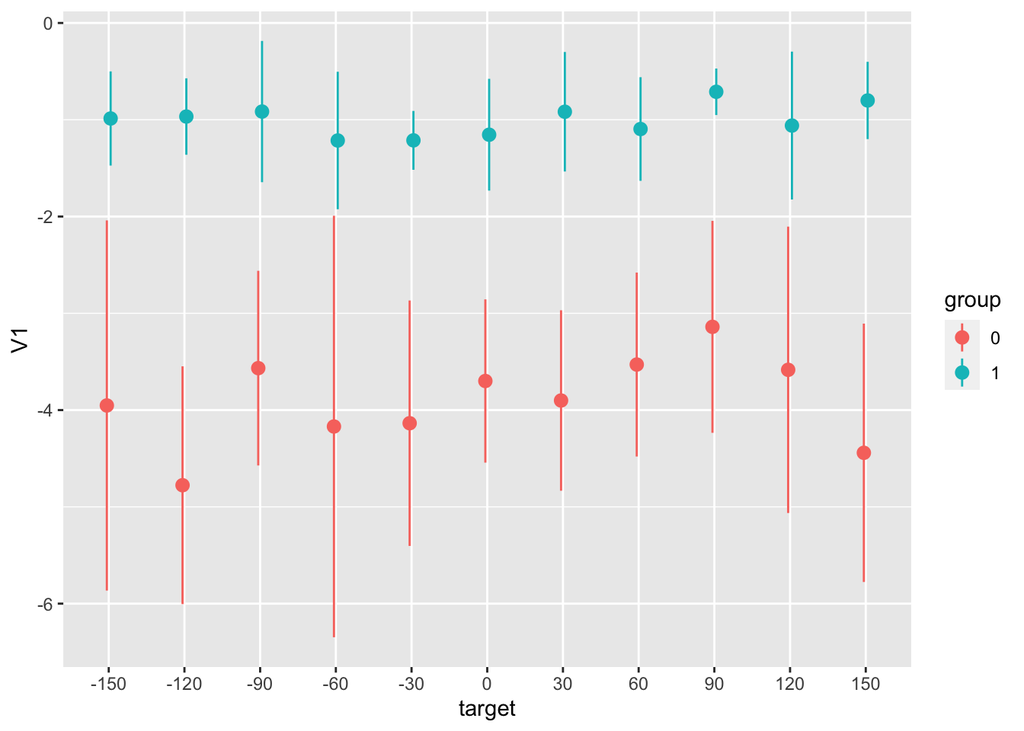

```r
ddd <- dd[, .(mean(V1), sd(V1)/sqrt(length(unique(target))*length(unique(group)))), .(group, target)]
ggplot(ddd, aes(target, V1, colour=group)) +
  geom_pointrange(aes(ymin=V1-V2, ymax=V1+V2), position=position_dodge(width=.1))
```

```r
## To my eye, it looks like the effect of group ought to be
## significant, or pretty close to it, but that's probably
## about it.

## Verify results
options(contrasts = c("contr.sum","contr.poly")) # type 3 ss
fm <- lm(V1 ~ group * target, data=dd)
anova(fm)
```

```
## Analysis of Variance Table
##
## Response: V1
##               Df Sum Sq Mean Sq  F value Pr(>F)
## group          1 461.40  461.40 431.8110 <2e-16 ***
## target        10  13.45    1.35   1.2589 0.2561
## group:target  10  10.80    1.08   1.0106 0.4358
## Residuals    198 211.57    1.07
## ---
## Signif. codes:  0 '***' 0.001 '**' 0.01 '*' 0.05 '.' 0.1 ' ' 1
```

```r
ezANOVA(data=dd,
        dv=V1,
        wid=subject,
        between=.(group, target),
        type=3)
```

```
## Coefficient covariances computed by hccm()
```

```
## $ANOVA
##         Effect DFn DFd          F            p p<.05        ges
## 2        group   1 198 431.811012 1.207998e-51     * 0.68561998
## 3       target  10 198   1.258945 2.560987e-01       0.05978197
## 4 group:target  10 198   1.010574 4.358029e-01       0.04856061
##
## $`Levene's Test for Homogeneity of Variance`
##   DFn DFd      SSn      SSd        F            p p<.05
## 1  21 198 37.66427 72.21667 4.917428 5.462064e-10     *
```